# Flights Analysis

Author

Gordon Goodwin

In this project, we’ll take the perspective of a data analyst working for a **major overseas airline company** called `GG Airlines` that is contemplating an **expansion into the U.S. domestic air market**.

The company’s C.E.O wants to start small with an **initial 5-plane investment** before committing further resources, and has us asked us to identify **key drivers of flight profitability** and recommend a **set of optimal routes** given company objectives and constraints.

# 1 Objective

The goal of this analysis is to support GGA’s expansion by using 1Q2019 U.S. aviation data to recommend **5 potential round-trip routes** based on **volume, profitability, and any other relevant KPIs**.

## 1.1 Background

- Only direct dual-leg round-trip routes between medium or large U.S. airports were considered
  - Origin of Leg 1 = Destination of Leg 2 (`CLT` - `RDU` - `CLT`)
- Each of the 5 planes will be dedicated to a single route (5 planes, 5 routes)
- Punctuality is a core component of the GGA brand

## 1.2 Profitability Objective Function

Profitability was first calculated at the individual flight level and then aggregated across routes and carriers (discussed further later). At a high level, profitability can be broken down into:

$$Profit = [(Baggage + Fare)*Passengers]-[(OpCosts*Distance) + Delays + AirportCost]$$

**Further detail regarding calculations and relevant assumptions can be found in the Appendix**

# 2 Data Prep & Exploration

This project uses aviation data from the first quarter of 2019, combining information from three datasets on `flights`, `tickets`, and `airports`. The preliminary datasets were explored, transformed, and merged to create a final dataset organized with **one row per round-trip flight**. Each round-trip flight is uniquely identified by a combination of: `carrier_code`, `plane_tail_number`, `carrier_flight_number`, and `flight_date`.

```r
# No Scientific Mode for numeric vars
options(scipen = 999)

# Source Fns
source("Airline Functions.R")

# List Data CSV Files in working directory
list.files(pattern = ".csv") -> files2load

# Iteratively load filelist and clean names while loading
map(files2load, cleanreader) -> filelist

# name dataframes to match corresponding filepath name
names(filelist) <- str_to_lower(str_remove_all(files2load, ".csv"))

## Assign objects
list2env(filelist, .GlobalEnv)

# Remove list to clear memory
rm(filelist)
```

**The above code will import all CSV files currently residing in your working directory simultaneously.**

## 2.1 Flights

After loading our `flights` dataset, we perform some basic clean-up steps by parsing the `distance` and `flight_date` fields, removing duplicate records, and filtering out flights that are cancelled or whose origin and destination IATA codes are the same.

```r
# Replace fl_date, clean/parse distance from character to numeric variable
flights |>
  mutate(
    fl_date = datefixer(fl_date),
    distance = str_replace_all(str_remove_all(distance, "\\.0"), "^-?0+", ""),
    distance = abs(parse_number(distance))
  ) |>
  # De-Dupe
  distinct() |>
  # Format names for later join and clarity
  rename(origin_iata = origin,
         destin_iata = destination) |>
  # Remove flights where origin = destination, flight is cancelled, or distance invalid
  filter(origin_iata != destin_iata,
         cancelled == 0) -> flights
```

As Figure 1 shows below, while 5 variables in the `flights` dataset are missing values, only `air-time` and `arrival_delays` register more than 0.01% missingness. On the whole, none of the `flights` variables initially appear to be missing an impactful number of data points

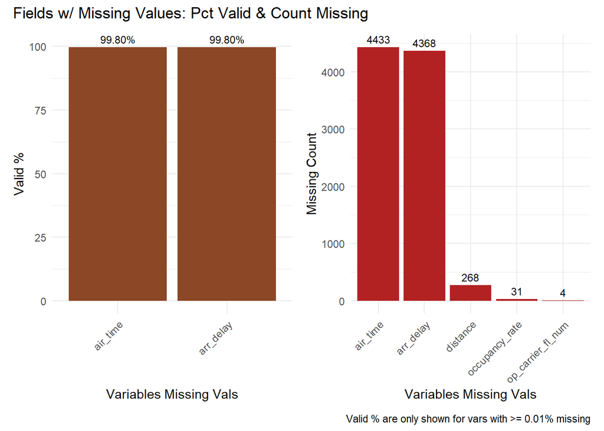

Figure 1: Missingness patterns for variables missing values

```r
flights |>
  missingval_viz()
```

Lastly, records for flights missing values on any of the `arrival_delay`, `occupancy_rate`, `distance`, or `flight_number` variables are removed, as those fields are all necessary for profitability calculations.

```r
# Filter out flights missing vars needed for profit aside from distance
flights |>
  filter(!is.na(op_carrier_fl_num),
         !is.na(arr_delay),
         !is.na(occupancy_rate),
         !is.na(distance)) -> flights
```

## 2.2 Airports

In order to facilitate joining the `airport` data to the `flights` data, the `airports` dataset needs to be cleaned and structured in a format with 1 row for each possible combination of origin and destination airports.

### 2.2.1 Airport Data Clean-Up

We begin by parsing `latitude` and `longitude` from the `coordinates` field, removing duplicates, and establishing origin and destination fields.

```r
airport_codes |>
  # De-dupe
  distinct() |>
  # Separate Lat/Longitude and convert to Numeric form
  separate_wider_delim(cols = coordinates,
                       delim = ", ",
                       names = c("latitude","longitude")) |>
  mutate(across(.cols = c("latitude", "longitude"),
                .fns = ~as.numeric(.x))) |>
  # Create origin and destin cols necessary for join with flights data
  mutate(origin_iata = iata_code,
         origin_type = type,
         destin_iata = iata_code,
         destin_type = type,
         origin_latitude = latitude,
         origin_longitude = longitude,
         destin_latitude = latitude,
         destin_longitude = longitude) -> airport_codes
```

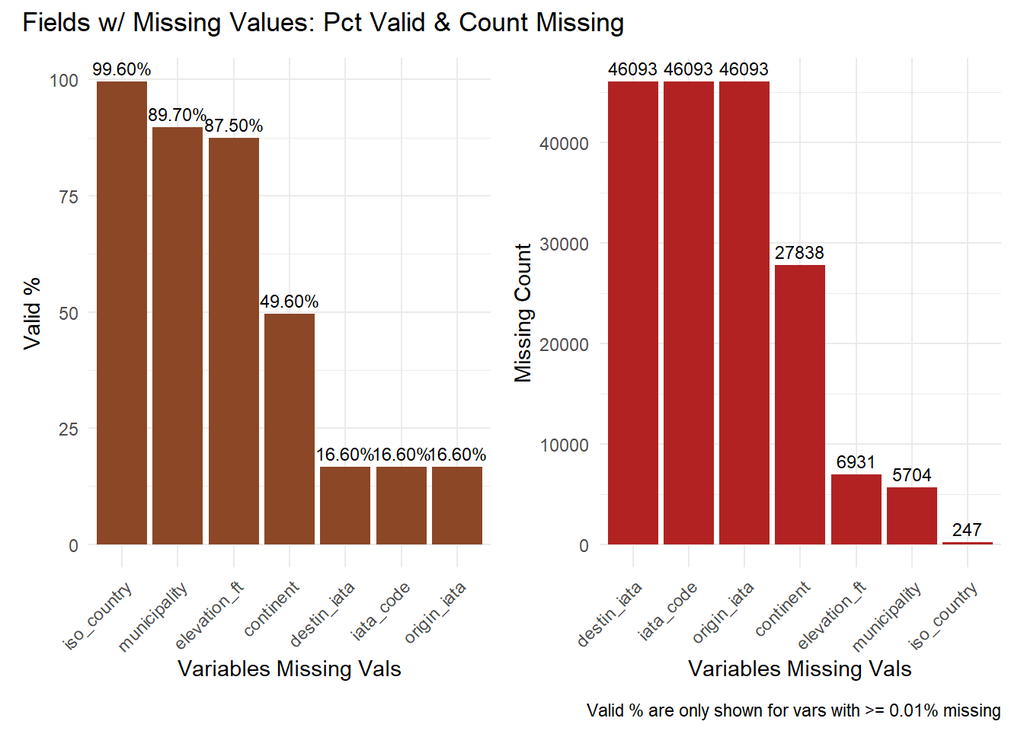

Figure 2: Initial missingness for airport_codes data

```r
airport_codes |> missingval_viz()
```

Lastly, after filtering for just U.S. med/large airports, Figure 3 shows that 96% of the `iata_code` records are now valid.

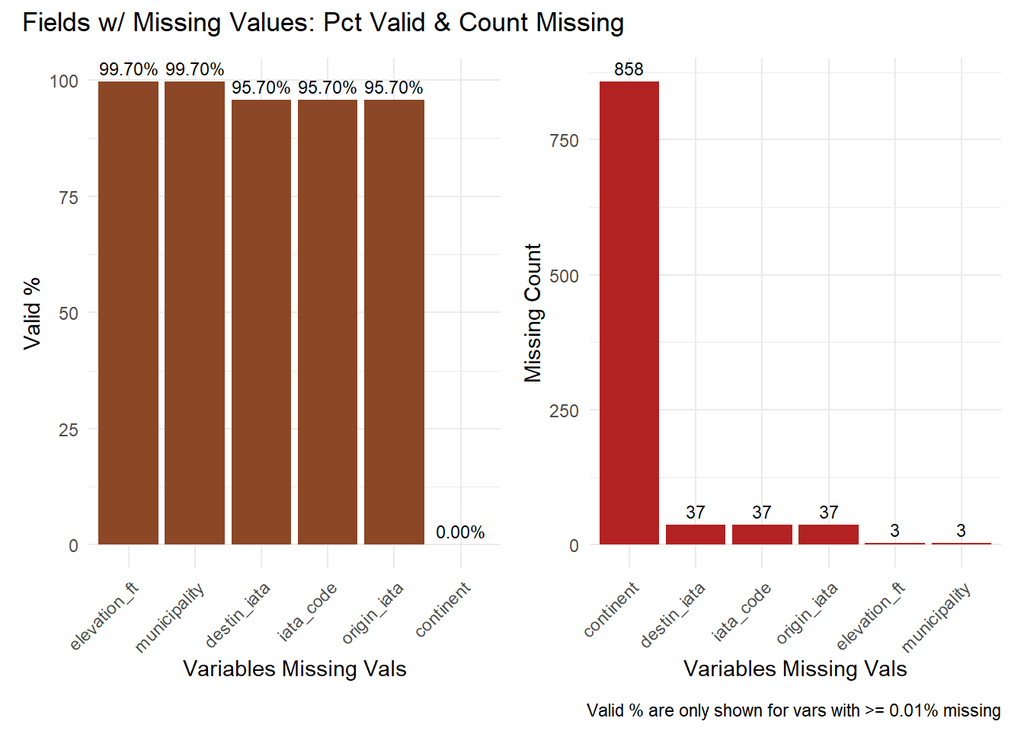

Figure 3: revised missingness for airport_codes data

```r
# Filter for just US medium/large airports
airport_codes |>
  filter(iso_country == "US",
         type %in% c('medium_airport',"large_airport")) -> airport_codes_medlarge

airport_codes_medlarge |> missingval_viz()
```

As `iata_code` is required to join to our `flights` data, we remove any remaining NA records.

```r
# Remove missing iata code
airport_codes_medlarge |>
  filter(!is.na(iata_code)) -> airport_codes_medlarge
```

**Several IATA codes were shared by an open and a closed airport, but only one (Austin) was a med/large U.S. airport**

### 2.2.2 Airports Data Self-Join

For the final formatting step, the `airports` data is self-joined to create a full cross-product grid of all possible origin and destination pairs of medium/large U.S. airports.

```r
# Create grid of crossprods of origin and destination for flights data join
airport_codes_medlarge |>
  # Cross Product Grid
  crossprodder(complete = F,
               origin_iata, destin_iata) |>
  # Inner Join back to self to pull in origin section metadata
  inner_join(airport_codes_medlarge |>
               select(origin_iata, origin_type,
                      origin_latitude, origin_longitude),
             by = "origin_iata") |>
  # Inner Join back to self to pull in destination section metadata
  inner_join(airport_codes_medlarge |>
               select(destin_iata, destin_type,
                      destin_latitude, destin_longitude),
             by = "destin_iata") -> airport_codes_medlarge

# Glimpse
airport_codes_medlarge |>
  slice_sample(n = 3) |>
  select(origin_iata, origin_type, destin_iata, destin_type) |>
  gt() |>
  tab_header(title = md("**Random Sample of Airport Grid for Validation**"))
```

**Random Sample of Airport Grid for Validation**

| origin_iata | origin_type | destin_iata | destin_type |
| --- | --- | --- | --- |
| TCM | large_airport | ECG | medium_airport |
| CVO | medium_airport | EWN | medium_airport |
| MYL | medium_airport | BMI | large_airport |

## 2.3 Merge Flights & Airports Data

The cross-product grid of origin/destination `airport` pairs is then joined to the `flights` data to create an intermediate dataset containing both origin and destination medium/large `flights` and `airports` data. First, the fields in both datasets are compared to derive the primary keys (`origin_iata`, `destin_iata`)

```r
# Cross-check common and unique columns before join
compare_df_cols(airport_codes,
                flights)
```

```
$common_cols
[1] "origin_iata" "destin_iata"

$unique_cols
$unique_cols[[1]]
 [1] "type"             "name"             "elevation_ft"     "continent"
 [5] "iso_country"      "municipality"     "iata_code"        "latitude"
 [9] "longitude"        "origin_type"      "destin_type"      "origin_latitude"
[13] "origin_longitude" "destin_latitude"  "destin_longitude"

$unique_cols[[2]]
 [1] "fl_date"           "op_carrier"        "tail_num"
 [4] "op_carrier_fl_num" "origin_airport_id" "origin_city_name"
 [7] "dest_airport_id"   "dest_city_name"    "dep_delay"
[10] "arr_delay"         "cancelled"         "air_time"
[13] "distance"          "occupancy_rate"
```

```r
# Store common cols as primary keys
compare_df_cols(airport_codes,
                flights)$common_cols -> primarykeys_airports_flights
```

Next, the join is performed and the output validated:

```r
# inner join flights to med/large US airport origin/destination pairs
flights |>
  inner_join(airport_codes_medlarge,
             by = primarykeys_airports_flights) -> flights_medlarge

# Check
flights_medlarge |>
  select(op_carrier, tail_num, origin_iata, origin_city_name,origin_type,
         destin_iata, dest_city_name,destin_type) |>
  head(n = 1) |>
  gt() |>
  tab_header(title = md("**Validation Sample Showing Airport Info Pulled In**"))
```

**Validation Sample Showing Airport Info Pulled In**

| op_carrier | tail_num | origin_iata | origin_city_name | origin_type | destin_iata | dest_city_name | destin_type |
| --- | --- | --- | --- | --- | --- | --- | --- |
| WN | N955WN | RSW | Fort Myers, FL | large_airport | CLE | Cleveland, OH | large_airport |

## 2.4 Round-Trip Routes

```r
# Round Trip identified by: origin 1 = dest 2, dest 2 = origin 1
flights_medlarge |>
  # Self Join where "Right" side = Leg 1, "Left" side = Leg 2
  inner_join(flights_medlarge,
             by = c("op_carrier",
                    "op_carrier_fl_num",
                    "tail_num","fl_date"),
             relationship = "many-to-many",
             suffix = c("_leg1","_leg2")) |>
  filter(
    # Filter for round trip: origin 1 = dest 2, dest 2 = origin 1
    origin_iata_leg1 == destin_iata_leg2,
    destin_iata_leg1 == origin_iata_leg2
  ) |>
  arrange(op_carrier, fl_date, op_carrier_fl_num,fl_date) -> flights_medlarge_roundtrip
```

Before checking the final results, a few final clean-up steps are taken to:

- Create a single-field round-trip route identifier (e.g. `CLT-RDU`)
- Filter out the now-redundant secondary rows for each round-trip flight
  - (all necessary info for both legs is now in a single row).
- Create custom `distance_crowfly` fields using point-to-point calculations from the `latitude` and `longitude` fields to validate the original `distance` values.

```r
flights_medlarge_roundtrip |>
  # round all numeric cols to 2 digits for clarity
  mutate(across(where(is.numeric),
                ~round(.x, 2))) |>
  # Create single field identifying the route and calculate crow-fly distance
  mutate(route_iata = paste(origin_iata_leg1, destin_iata_leg1, sep = "-"),
         route_city_name = paste(origin_city_name_leg1,
                                 dest_city_name_leg1, sep = "-"),
         # Crow-Fly distance for each leg and then total crow fly
         distance_crowfly_leg1 = crowfly_distance_miles(lat1 = origin_latitude_leg1,
                                                        lon1 = origin_longitude_leg1,
                                                        lat2 = destin_latitude_leg1,
                                                        lon2 = destin_longitude_leg1),
         distance_crowfly_leg2 = crowfly_distance_miles(lat1 = origin_latitude_leg2,
                                                        lon1 = origin_longitude_leg2,
                                                        lat2 = destin_latitude_leg2,
                                                        lon2 = destin_longitude_leg2),
         distance_crowfly_total = distance_crowfly_leg1 + distance_crowfly_leg2) |>
  # Round to 2 digits for numeric cols
  mutate(across(.cols = where(is.numeric),
                .fns = ~round(.x, 2))) |>
  # De-Dupe
  distinct() |>
  # Filter out redundant secondary rows for each flight
  # we have 1 row per round-trip flight with all info for both legs on 1 row
  filter(row_number() == 1,
         .by = c(fl_date, op_carrier,
                 tail_num, op_carrier_fl_num)) -> flights_medlarge_roundtrip

# Random sample a few rows to validate process
flights_medlarge_roundtrip |>
  slice_sample(n = 3) |>
  select(origin_iata_leg1, destin_iata_leg1, distance_leg1,
         origin_iata_leg2, destin_iata_leg2, distance_leg2) |>
  gt() |>
  tab_header(title = md("**Random Sample of Round-Trips to Validate**"))
```

**Random Sample of Round-Trips to Validate**

| origin_iata_leg1 | destin_iata_leg1 | distance_leg1 | origin_iata_leg2 | destin_iata_leg2 | distance_leg2 |
| --- | --- | --- | --- | --- | --- |
| CLT | CMH | 347 | CMH | CLT | 347 |
| DTW | EWR | 488 | EWR | DTW | 488 |
| GEG | MSP | 1175 | MSP | GEG | 1175 |

Last, the `distance_crowfly` metrics are used to quickly validate the original `distance` values. As seen below in Figure 4 for the `Charlotte-Raleigh` route, the 2 values aren’t identical but are close enough to be confident in the original `distance` values.

```r
# Display improvement for Charlotte to RDU
flights_medlarge_roundtrip |>
  filter(route_iata == "CLT-RDU") |>
  distinct(route_iata, distance_leg1, distance_crowfly_leg1) |>
  gt() |>
  tab_header(title = md("**Original and Custom Distance Metrics**"),
             subtitle = md("*Charlotte-Raleigh route*"))
```

**Original and Custom Distance Metrics**

*Charlotte-Raleigh route*

| route_iata | distance_leg1 | distance_crowfly_leg1 |
| --- | --- | --- |
| CLT-RDU | 130 | 148.78 |

Figure 4: Distance Values Inaccurately Low

**While crowfly_distance has relatively inaccurate raw values, it correctly rank orders routes by distance**

## 2.5 Tickets

The final `tickets` data contains a sample of tickets that can be joined to our `flights/airports` data to get `ticket_fare` information for the profitability calculations.

### 2.5.1 Tickets Data Clean-Up

To prepare the `tickets` data to be joined to our `flights/airports` data, initial clean-up steps are taken to remove duplicates, retain only round-trip flights, parse the ticket_fare values, and create an origin/destination structure.

```r
# De-Dupe and filter for round trip
tickets |>
  # De-Dupe
  distinct() |>
  # Keep only round-trip
  filter(roundtrip == 1) |>
  # Parse ticket fare
  mutate(itin_fare = parse_number(itin_fare)) |>
  # Rename fields to be consistent with flights/airports data
  rename(origin_iata_leg1 = origin,
         destin_iata_leg1 = destination,
         op_carrier = reporting_carrier) |>
  mutate(origin_iata_leg2 = destin_iata_leg1,
         destin_iata_leg2 = origin_iata_leg1,
         route_iata = paste(origin_iata_leg1,
                            destin_iata_leg1, sep = "-")) |>
  # Keep only necessary fields
  select(itin_id, op_carrier, route_iata,origin_iata_leg1, destin_iata_leg1,
         origin_iata_leg2, destin_iata_leg2, itin_fare) -> ticketsround
```

As seen below in Figure 5, a small proportion of `ticket_fare` values are missing.

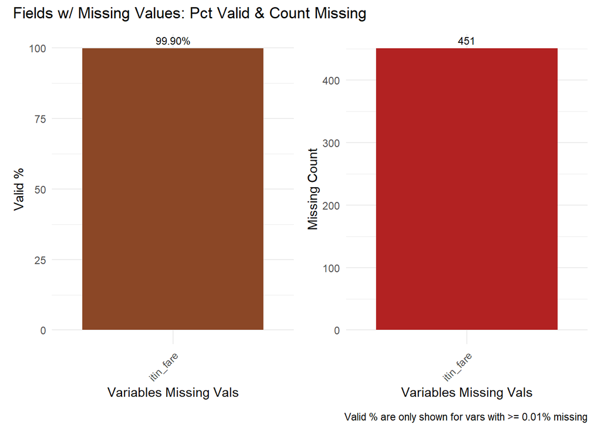

Figure 5: Missing data for round-trip tickets

```r
# Missing tickets values for round trip routes
ticketsround |> missingval_viz()
```

Those records are removed, as `ticket_fare` is needed for profitability calculations.

```r
ticketsround |> filter(!is.na(itin_fare)) -> ticketsround
```

### 2.5.2 Aggregate Tickets Data

Initially the plan was to calculate an `average_ticket_fare` for each `route`, but review of the `ticket_fare` distribution in Figure 6 shows significant price variability amongst carriers, along with several major outliers

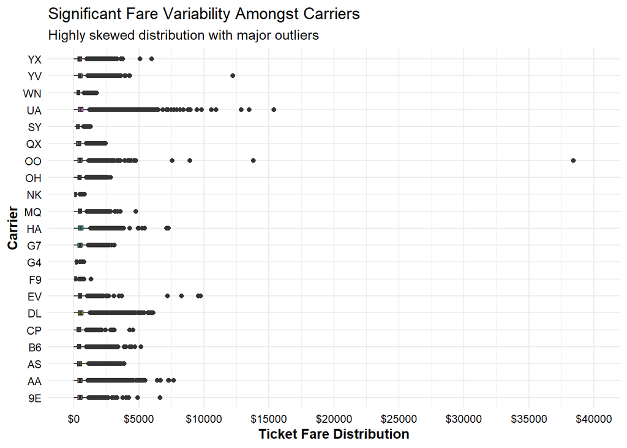

Figure 6: Boxplots of fare prices by carrier

```r
# Significant inter-carrier fare variability and outliers
ticketsround |>
  doublebox_viz(op_carrier, itin_fare) +
  labs(x = "Carrier", y = "Ticket Fare Distribution",
       title = "Significant Fare Variability Amongst Carriers",
       subtitle = "Highly skewed distribution with major outliers") +
  scale_y_continuous(limits = c(0, 40000),
                     breaks = seq(0, 40000, 5000),
                     labels = \(x) paste0("$",x))
```

Given the carrier variability, skewness, and outliers, a group-wise median was calculated to assign `median_ticket_fare` values to each `route` and `carrier` combination. A trimmed mean was also calculated for data exploration.

```r
# Trimmed Avg and Median fares calculated, only median will be used
ticketsround |>
  summarize(avg_fare = roundmean(x = itin_fare, trim = 0.1),
            med_fare = median(itin_fare),
            .by = c(route_iata,
                    op_carrier)) -> ticketsround_summary

# Preview
ticketsround_summary |>
  filter(route_iata=="CLT-RDU") |>
  head() |>
  gt() |>
  tab_header(title = md("**Validation Preview of Fare Summary Metrics**"))
```

**Validation Preview of Fare Summary Metrics**

| route_iata | op_carrier | avg_fare | med_fare |
| --- | --- | --- | --- |
| CLT-RDU | AA | 328.6 | 382 |
| CLT-RDU | OH | 1159.0 | 1159 |

## 2.6 Merge Tickets to Flights/Airports

The final `flights/airports/tickets` dataset is created by left-joining the `tickets` `route` and `carrier`-level summary data on fare prices to the `flights/airports` data. A left-join was used in case not all `routes` and `carriers` in the flights data are present in the `tickets` data. In such cases where `ticket_fare` values were in fact missing for a specific `carrier`, the `route`-level median was imputed. If `route`-level fares were unavailable, the `median_imputed_fare` was left `NA`.

```r
# Comparison of Common Cols to be used as primary keys for join
compare_df_cols(ticketsround_summary, flights_medlarge_roundtrip)$common_cols -> primarykeys_tickets_airports_flights

# Join med large round trip routes to tickets data
flights_medlarge_roundtrip |>
  left_join(ticketsround_summary,
            by = c(primarykeys_tickets_airports_flights)) |>
  ## Impute Mean/Median of route (across all carriers) where possible
  mutate(avg_fare_imputed = if_else(is.na(avg_fare),
                                    roundmean(avg_fare, na.rm = T),
                                    avg_fare),
         med_fare_imputed = if_else(is.na(med_fare),
                                    median(med_fare, na.rm = T),
                                    med_fare),
         .by = c(route_iata)) -> flights_medlarge_roundtrip
```

Lastly, a quick validation check shows that none of the `routes` that still have missing `ticket_fare` values are in the top 50 busiest `routes`

- the lack of output indicates there were no top 50 routes that matched the `NA` `ticket_fare` criteria

As `ticket_fares` are needed for profitability, and the removal impact is likely to be minimal, the remaining records with missing values were removed.

```r
# Top 50 Routes
flights_medlarge_roundtrip |>
  count(origin_iata_leg1, destin_iata_leg1,route_iata, sort = T) |>
  slice_head(n = 50) -> top50routes

# Check if any flights missing ticket fares are in top 50 busiest (NO)
flights_medlarge_roundtrip |>
  filter(is.na(med_fare_imputed)) |>
  inner_join(top50routes)

# Remove remaining NA
flights_medlarge_roundtrip |> filter(!is.na(med_fare_imputed)) -> flights_medlarge_roundtrip
```

# 3 Profitability Calculations

The last step is to calculate the `cost`, `revenue`, and `profit` for each flight, which will allow for analytical aggregation up to the `route` and `carrier` level. To facilitate data exploration and validation, profitability metrics are calculated for both the individual legs and the overall round-trip flight.

## 3.1 Revenue

Revenue is comprised of `ticket_fare` and `baggage_fee` components, both of which are impacted by `passenger_counts`. To derive `passenger_counts`, the `occupancy_rates` are multiplied by an assumed max capacity of 200 passengers. These `passenger_counts`in turn serve as multipliers for the `median_ticket_fare` and `baggage_fee` calculations.

```r
# TICKET Fees = Median Fare * Estimated Passenger Count
flights_medlarge_roundtrip |>
  mutate(n_passengers_leg1 = occupancy_rate_leg1*200,
         n_passengers_leg2 = occupancy_rate_leg2*200,
         n_passengers_total = n_passengers_leg1 + n_passengers_leg1,
         avg_occ_rate_bothlegs = round(n_passengers_total/400, 2)) |>
  mutate(est_fare_revenue_total = n_passengers_total*med_fare_imputed) |>
# Baggage Fees = $35 * Total Number Passengers * 0.5 bags per passenger
  mutate(n_bags_leg1 = n_passengers_leg1*0.5,
         n_bags_leg2 = n_passengers_leg2*0.5,
         n_bags_total = n_passengers_leg1 + n_passengers_leg2,
         est_bag_revenue_total = n_bags_total*35) |>
  # Total Revenue Calc = Bag Rev + Fare Rev
  mutate(est_all_revenue_total = est_bag_revenue_total + est_fare_revenue_total) -> flights_medlarge_roundtrip
```

## 3.2 Costs

Costs are comprised of `mileage_variable`, `airport_size`, and `delay_time` components. The `mileage_variable` costs are determined by an assumed $9.18 fee per `distance` mile traveled and the `airport_size` costs are based on a $5k/$10k charge for medium/large airports. The `delay_time` costs are based on a $75/min charge applied to each `arrival` and `departure` for each minute of `delay_time` past a 15-minute grace period.

```r
# Mileage-variable costs
flights_medlarge_roundtrip |>
  mutate(mileage_var_costs_leg1 = 9.18*distance_leg1,
         mileage_var_costs_leg2 = 9.18*distance_leg2,
         mileage_var_costs_total = mileage_var_costs_leg1 + mileage_var_costs_leg2) |>
  # Airport Cost = if med then 5k, if large then 10k
  mutate(destin_airport_cost_leg1 = if_else(destin_type_leg1 == "large_airport",
                                            true = 10000,
                                            false = 5000),
         destin_airport_cost_leg2 = if_else(destin_type_leg2 == "large_airport",
                                            true = 10000,
                                            false = 5000),
         airport_landing_cost_total = destin_airport_cost_leg1 + destin_airport_cost_leg2) |>
  # Departure/Arrival Delay > 15min = $75/min
  # Subtract 15min grace period from all 4 flight legs
  mutate(across(.cols = contains("delay"),
                .fns = ~.x-15,
                .names = "{.col}_adj")) |>
  # Zero trunc adjusted delay time for all 4 flight legs
  mutate(across(.cols = contains("_adj"),
                .fns = ~zero_trunc(.x))) |>
  # Total adjusted delay time summed across all 4 flight legs
  mutate(arr_dep_delay_time_total = (dep_delay_leg1_adj +
                                       arr_delay_leg1_adj +
                                       dep_delay_leg2_adj +
                                       arr_delay_leg2_adj)) |>
  # Delay costs based on adjusted delay times for all 4 flight legs
  mutate(dep_delay_cost_leg1 = dep_delay_leg1_adj*75,
         arr_delay_cost_leg1 = arr_delay_leg1_adj*75,
         dep_delay_cost_leg2 = dep_delay_leg2_adj*75,
         arr_delay_cost_leg2 = arr_delay_leg2_adj*75) |>
  # Total delay cost based on summing across delay costs for 4 legs
  mutate(arr_dep_delay_cost_total = (dep_delay_cost_leg1 +
                                       dep_delay_cost_leg2 +
                                       arr_delay_cost_leg1 +
                                       arr_delay_cost_leg2)) |>
# Total Costs = milage variable + airport + delay
  mutate(est_all_costs_total = mileage_var_costs_total +
           airport_landing_cost_total +
           arr_dep_delay_cost_total) -> flights_medlarge_roundtrip
```

## 3.3 Profit

Profit is calculated for each individual round-trip flight by subtracting the flight-level `total_costs` from the `total_revenue`.

```r
# Total Profit = Total Revenue - Total Cost
flights_medlarge_roundtrip |>
  mutate(est_profit_total = est_all_revenue_total - est_all_costs_total) -> flights_medlarge_roundtrip

# Validate
flights_medlarge_roundtrip |>
  slice_sample(n = 1) |>
  select(route_iata,op_carrier,tail_num, est_profit_total,est_all_revenue_total,est_all_costs_total) |> gt() |>
  tab_header(title = md("**Validation Sample of Flight-Level Profit Metrics**"))
```

**Validation Sample of Flight-Level Profit Metrics**

| route_iata | op_carrier | tail_num | est_profit_total | est_all_revenue_total | est_all_costs_total |
| --- | --- | --- | --- | --- | --- |
| ATL-SYR | DL | N908DA | 67062.16 | 101640 | 34577.84 |

# 4 Findings

We can now use our final dataset to evaluate each `route` and/or `route/carrier` combo using a variety of KPIs.

## 4.1 Top 10 Busiest Routes

At the `route`-level, we can see in Figure 7 that the `LA-SanFran` (`LAX-SFO`) route was the busiest overall route in 1Q2019, followed closely by a number of routes based out of `Atlanta`.

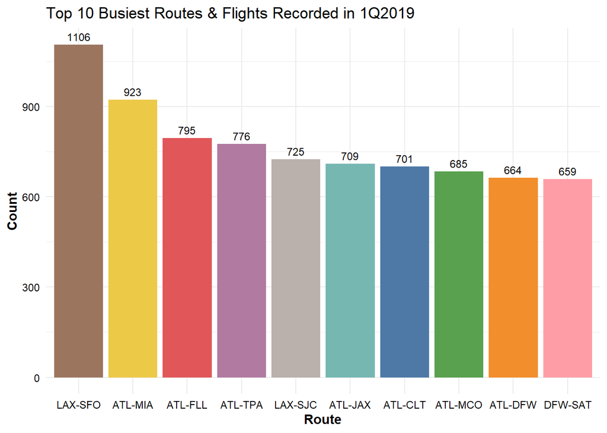

Figure 7: Routes with the greatest number of flights

```r
## Top 10 Flights Bar Chart
### Round
flights_medlarge_roundtrip |>
  singlebar_viz(x = route_iata, nrecs = 10) +
  labs(x = "Route",
       title = "Top 10 Busiest Routes & Flights Recorded in 1Q2019")
```

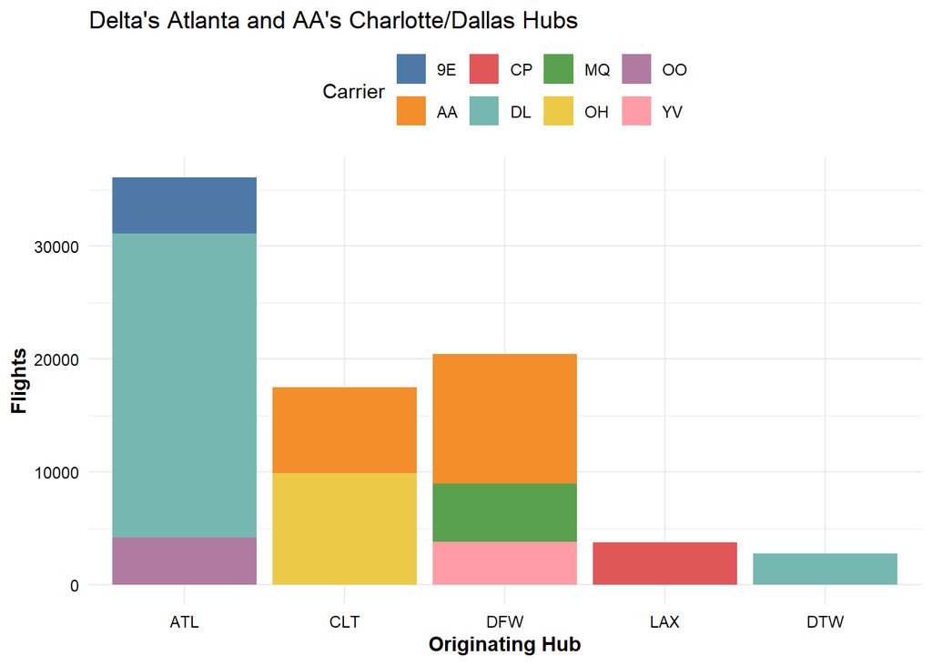

Figure 8: Originating airports with greatest number of flights

```r
flights_medlarge_roundtrip |>
  doublebar_viz(x = origin_iata_leg1,grp1 = op_carrier, nrecs = 10, labels = F) +
  labs(x = "Originating Hub", y = "Flights", fill = "Carrier",
       title = "Delta's Atlanta and AA's Charlotte/Dallas Hubs")
```

Accordingly, `route/carrier` combinations were probed to see which routes operated by specific carriers were the busiest. As shown below in Figure 9, `Delta` (`DL`) had the greatest number of 1Q2019 flights by far, the majority of which originated out of its main hub in `Atlanta (ATL)`. Interestingly, there were no individual `route/carrier` combinations that appeared overwhelmingly busier.

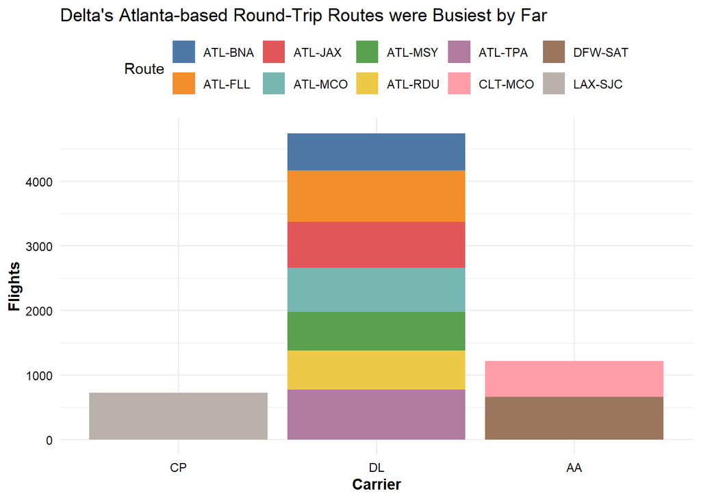

Figure 9: Route-Carrier combos with greatest number of flights

```r
flights_medlarge_roundtrip |>
  doublebar_viz(x = op_carrier,grp1 = route_iata, nrecs = 10, labels = F) +
  labs(x = "Carrier", y = "Flights", fill = "Route",
       title = "Delta's Atlanta-based Round-Trip Routes were Busiest by Far")
```

## 4.2 Top 10 Profitable Routes

In orderto probe high-level profitability, estimates for each individual round-trip flight were aggregated across `routes` and `route/carrier` combinations. The `route` and `route/carrier`-level profit estimates were then rank-ordered to derive the top 10 results.

**The following profitability estimates represent two levels of summary data, as first the group-wise median fares were imputed for flight-level estimates tjat were then averaged again to create route-level profitability**

### 4.2.1 Routes

As seen in Figure 10, while most of the top 10 routes generate an average profit of between $150,000 to $250,000, the `Vail, CO - New York` route (`EGE - JFK`) is a significant outlier that generates an average profit of over $500,000.

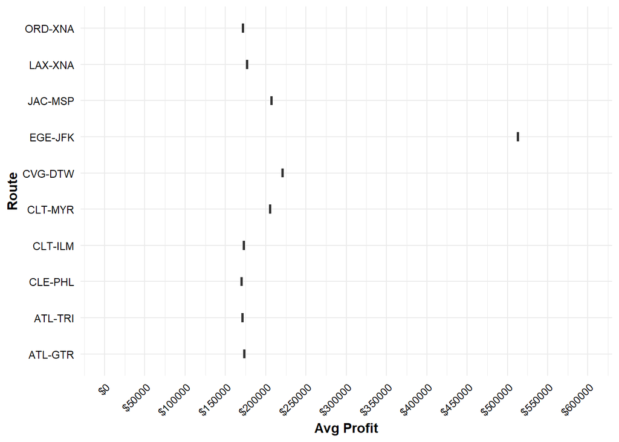

Figure 10: Top 10 routes by average profit

```r
options(scipen = 999)

# 10 Profitable Routes - Summary
flights_medlarge_roundtrip |>
  flightdicer(grp1 = route_iata,
             # grp2 = op_carrier,
              min_flights = 20) |>
  arrange(desc(avg_profit)) |>
  mutate(rank_profit = row_number()) |>
  slice_max(avg_profit, n = 10) |>
  mutate(across(.cols = (where(is.numeric) & !contains("occ")),
                .fns = ~round(.x))) -> top10routes_profit_summary

# Isolate just the routes for later comparisons
top10routes_profit_summary |> pull(route_iata) -> top10routes_profit

# Viz
top10routes_profit_summary |>
  doublebox_viz(x = route_iata,
                y = avg_profit) +
  labs(x = "Route",
       y = "Avg Profit") +
  scale_y_continuous(breaks = seq(0, 600000, by = 50000),
                     limits = c(0, 600000),
                     labels = \(x) paste0("$", x)) +
  theme(axis.text.x = element_text(angle = 45, vjust = 1, hjust = 1))
```

This generates 2 follow-up questions:

1. What is unique about the outlier `EGE-JFK` (`Vail, CO - New York`) route?
2. Is there significant variation across `carriers` within specific `routes`?
   1. e.g. Is a `route`-level estimate reliable?

#### 4.2.1.1 Vail, CO - New York

When comparing the `EGE-JFK` route to the other Top 10 profitable routes, Table 1 below shows us that:

- `Vail-NY` is a much lower-volume route, as while the `passenger_counts` are roughly equivalent, the total number of 1Q2019 `recorded_flights` is only 20% of the average flight count for the other top 10 routes
- `Vail-NY` flights cost about $25,000 more per flight on average, but generate **$350,000 more in average revenue** than the other Top 10 routes!

```r
# Create flag separating JFK-Vail route from other top 10 and get stats
top10routes_profit_summary |>
  mutate(route_jfk_ege = if_else(route_iata == "EGE-JFK",
                                 "Vail - NYC",
                                 "Other")) |>
  summarize(across(where(is.numeric),
                   ~roundmean(.x, digits = 0)),
            .by = route_jfk_ege) |>
  select(route_jfk_ege, n_flights, avg_profit,
         avg_n_passengers,avg_cost_total, avg_revenue_total) |>
  gt() |>
  tab_header(title = md("**Vail - NY has Greater Revenue than other Top 10**"))
```

Table 1: Vail - NY route vs other Top 10 routes

**Vail - NY has Greater Revenue than other Top 10**

| route_jfk_ege | n_flights | avg_profit | avg_n_passengers | avg_cost_total | avg_revenue_total |
| --- | --- | --- | --- | --- | --- |
| Vail - NYC | 54 | 512848 | 249 | 51595 | 564443 |
| Other | 243 | 185361 | 258 | 27279 | 212640 |

```r
#| label: tbl-vail_revenue_diffs

# Create flag separating JFK-Vail route and get revenue info
top10routes_profit_summary |>
  mutate(route_jfk_ege = if_else(route_iata == "EGE-JFK",
                                 "Vail - NYC",
                                 "Other")) |>
  summarize(across(.cols = where(is.numeric),
                   .fns = ~roundmean(.x, digits = 2)),
            .by = route_jfk_ege) |>
  select(route_jfk_ege, avg_occupancy_rate, avg_bag_revenue,
         avg_fare_revenue,avg_median_fare) |>
  gt() |>
  tab_header(title = md("**Vail - NY has 3x Higher Ticket Fares than other Top 10**"))
```

**Vail - NY has 3x Higher Ticket Fares than other Top 10**

| route_jfk_ege | avg_occupancy_rate | avg_bag_revenue | avg_fare_revenue | avg_median_fare |
| --- | --- | --- | --- | --- |
| Vail - NYC | 0.62 | 9094 | 555350 | 2228.00 |
| Other | 0.65 | 9046 | 203594 | 788.44 |

#### 4.2.1.2 Carrier Variability

Having determined that fare prices can be a significant driver of profit, particularly for low-volume routes, we now turn to Question 2 to probe possible profitability variations across `carriers` for these top 10 overall `routes`. As seen in Figure 11, the following top 10 overall routes do have significant differences across carriers:

- `Cincinatti-Detroit` (`CVG-DTW)`
- `Charlotte-Wilmington` (`CLT-ILM`)
- `Atlanta-Columbus, MS` `(ATL-GTR)`

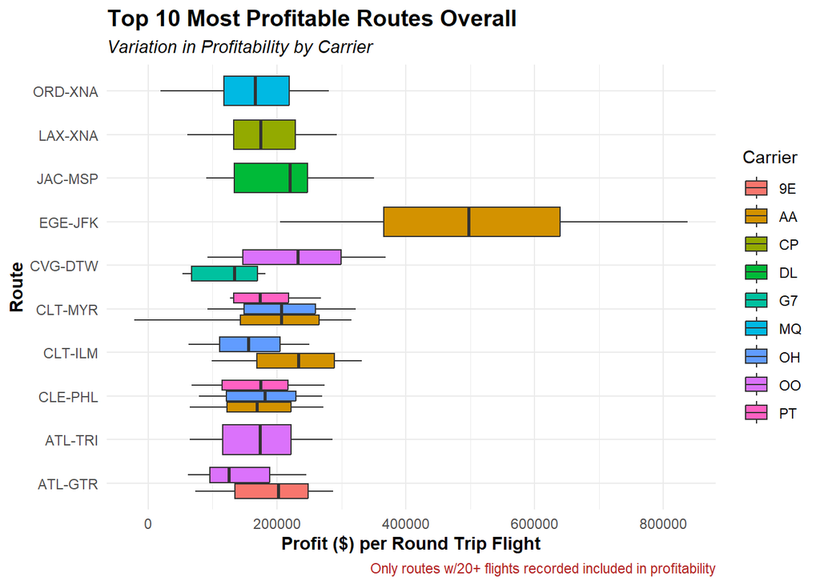

Figure 11: Carrier variability for top 10 profitable routes

```r
# Filter for those top 10 profitable routes and examine inter-carrier variation
flights_medlarge_roundtrip |>
  filter(route_iata %in% top10routes_profit) |>
  ggplot(aes(x = route_iata,
             fill = op_carrier,
             y = est_profit_total)) +
  geom_boxplot() +
  theme_minimal() +
  coord_flip() +
  theme(plot.title = element_text(face = "bold", size = 14),
        plot.subtitle = element_text(face = "italic"),
        plot.caption = element_text(color = "firebrick"),
        axis.title = element_text(face = "bold")) +
  labs(y = "Profit ($) per Round Trip Flight",
       fill = "Carrier",
       x = "Route",
       title = "Top 10 Most Profitable Routes Overall",
       subtitle = "Variation in Profitability by Carrier",
       caption = "Only routes w/20+ flights recorded included in profitability")
```

This is significant because it suggests that:

- Not all carriers experience the same profitability on these Top 10 routes
- There may be other routes that provide even greater profitability for specific carriers

### 4.2.2 Routes & Carriers

Given the inter-carrier variability in profit that was observed, profitability statistics were next calculated for specific `route/carrier` combos.

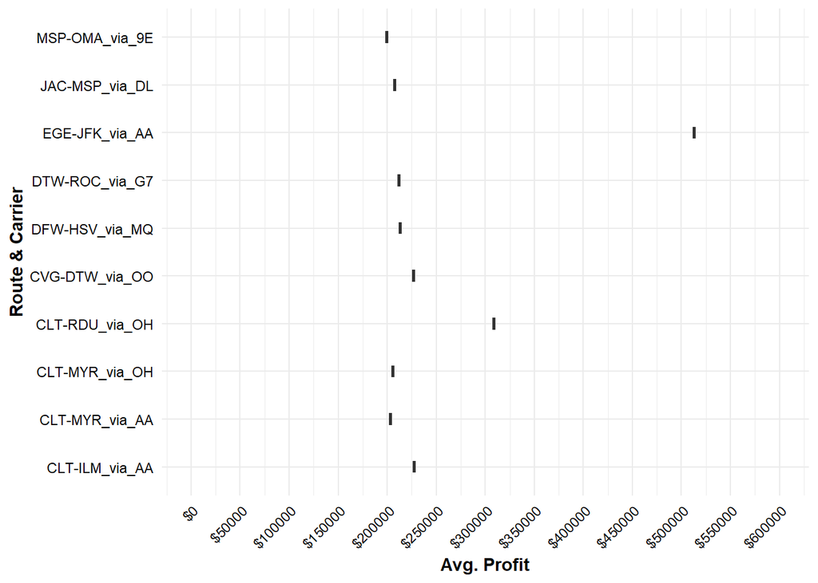

Figure 12: Top 10 routes & carriers ordered by average profit

```r
# 10 proftiable Route/Carrier Combos - Summary Stats
flights_medlarge_roundtrip |>
  flightdicer(grp1 = route_iata,
              grp2 = op_carrier,
              min_flights = 10) |>
   mutate(route_carrier = paste(route_iata, op_carrier, sep = "_via_")) |>
  arrange(desc(avg_profit)) |>
  mutate(rank_profit = row_number()) |>
  slice_max(avg_profit, n = 10) |>
  mutate(across(.cols = (where(is.numeric) & !contains("occ")),
                  .fns = ~round(.x))) -> top10routes_carriers_profit_summary

# Identify routes in overall top 10 profit and route/carrier version
top10routes_carriers_profit_summary |> pull(route_iata) -> top10routes_carriers_profit
top10routes_profit_summary |> pull(route_iata) -> top10routes_profit

# Visualize
top10routes_carriers_profit_summary |>
  doublebox_viz(x = route_carrier,
                y = avg_profit) +
  labs(x = "Route & Carrier",
       y = "Avg. Profit") +
  scale_y_continuous(breaks = seq(0, 600000, by = 50000),
                     limits = c(0, 600000),
                     labels = \(x) paste0("$", x)) +
  theme(axis.text.x = element_text(angle = 45, vjust = 1, hjust = 1))
```

- `CLT-RDU`, `DFW-HSV`, `DTW-ROC`, `MSP-OMA`

This can be seen in further detail by looking at the inter-carrier variation for these additional routes in Figure 13, where we see major differences in profit across carriers.

**Takeaway: Certain routes may in fact have the potential to be highly profitable but do not appear so at first due to lower-performing carriers**

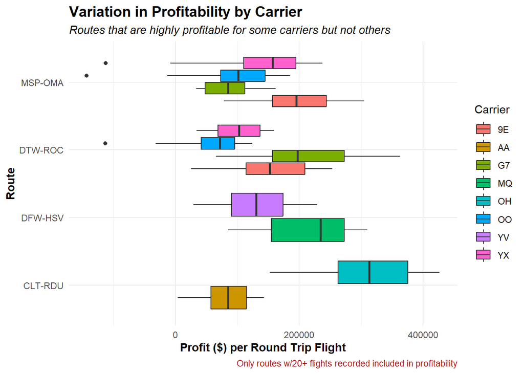

Figure 13: Top routes with major profit discrepancies across carriers

```r
# IATA route codes for the new top routes
setdiff(top10routes_carriers_profit, top10routes_profit) -> discreps

# Viz - Filter for newer top routes and show carrier variability
flights_medlarge_roundtrip |>
  filter(route_iata %in% discreps) |>
  ggplot(aes(x = route_iata,
             fill = op_carrier,
             y = est_profit_total)) +
  geom_boxplot() +
  theme_minimal() +
  coord_flip() +
  theme(plot.title = element_text(face = "bold", size = 14),
        plot.subtitle = element_text(face = "italic"),
        plot.caption = element_text(color = "firebrick"),
        axis.title = element_text(face = "bold")) +
  labs(y = "Profit ($) per Round Trip Flight",
       fill = "Carrier",
       x = "Route",
       title = "Variation in Profitability by Carrier",
       subtitle = "Routes that are highly profitable for some carriers but not others",
       caption = "Only routes w/20+ flights recorded included in profitability")
```

#### 4.2.2.1 Charlotte-Raleigh

Of particular note is the `Charlotte-Raleigh` `(CLT-RDU)` route, where the regional carrier `OH` (a subsidiary of `American Airlines AA`) generates a massively greater average profit than `AA`. As with the `Vail-NY` route, this difference is driven by higher `fare_prices`.

```r
flights_medlarge_roundtrip |>
  filter(route_iata == "CLT-RDU") |>
  summarize(avg_profit = roundmean(est_profit_total),
            avg_revenue = roundmean(est_all_revenue_total),
            avg_occupany = roundmean(avg_occ_rate_bothlegs),
            avg_fare = roundmean(med_fare_imputed),
            .by = op_carrier) |>
  gt() |>
  tab_header(title = md("**Revenue and Fare Differences for CLT-RDU Route**"),
             subtitle = md("*Regional subsidiary generates higher revenue due to 3.5x higher ticket prices*"))
```

Table 2: Charlotte-Raleigh differences in fares by carrier

**Revenue and Fare Differences for CLT-RDU Route**

| op_carrier | avg_profit | avg_revenue | avg_occupany | avg_fare |
| --- | --- | --- | --- | --- |
| AA | 85837.54 | 109192.8 | 0.65 | 382 |
| OH | 308462.58 | 331149.4 | 0.69 | 1159 |

#### 4.2.2.2 Profit, Revenue, Cost Interaction

Lastly, the distribution and trade-off relationships between profit and its constituent components is directly visualized below, along with callouts for the top 10 most-profitable.

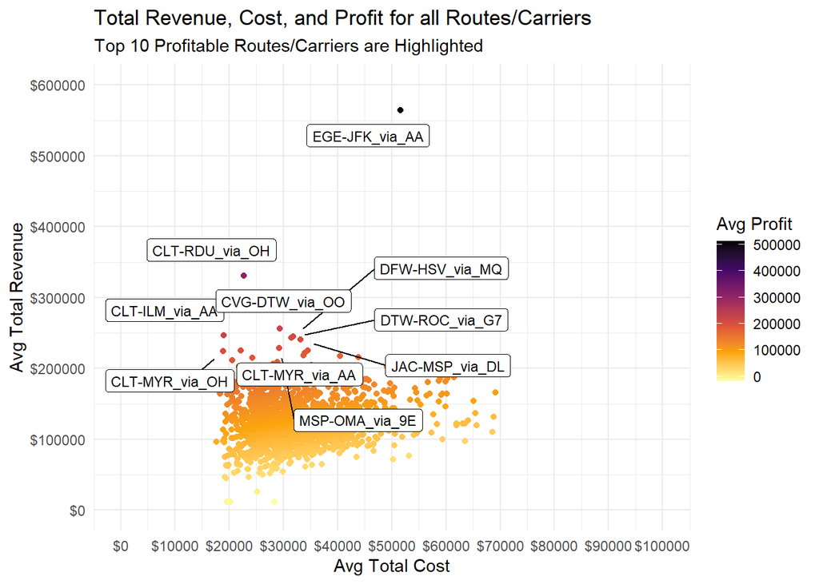

```r
#| label: fig-top10profit_tradeoff
#| fig-cap: Profit as a function of cost and revenue with top 10 highlighted

# Base plot of cost, revenue, profit
flights_medlarge_roundtrip |>
  flightdicer(grp1 = route_iata,
              grp2 = op_carrier,
              min_flights = 10) |>
  arrange(desc(avg_profit)) |>
  mutate(rank_profit = row_number()) |>
  #slice_max(avg_profit, n = 10) |>
  mutate(across(.cols = (where(is.numeric) & !contains("occ")),
                .fns = ~round(.x))) |>
  ggplot(aes(x = avg_cost_total,
             y = avg_revenue_total,
             color = avg_profit)) +
  geom_point() +
  theme_minimal() +
  scale_color_viridis_c(option = "inferno", direction = -1) +
  scale_y_continuous(limits = c(0, 600000),
                     breaks = seq(0, 600000, 100000),
                     labels = \(x) paste0("$",x)) +
  scale_x_continuous(limits = c(0, 100000),
                     breaks = seq(0, 100000, 10000),
                     labels = \(x) paste0("$",x)) +
  labs(x = "Avg Total Cost",
       y = "Avg Total Revenue",
       color = "Avg Profit",
       title = "Total Revenue, Cost, and Profit for all Routes/Carriers",
       subtitle = "Top 10 Profitable Routes/Carriers are Highlighted") -> p1

# Identify Top 10 profitable route/carrier combos to create labels
flights_medlarge_roundtrip |>
  flightdicer(grp1 = route_iata,
              grp2 = op_carrier,
              min_flights = 10) |>
  arrange(desc(avg_profit)) |>
  mutate(route_carrier = paste(route_iata, op_carrier, sep = "_via_")) |>
  slice_max(avg_profit, n = 10) |>
  select(route_carrier, avg_cost_total, avg_revenue_total, avg_profit) -> top10labels

# Add labels to main plot to call out top 10
p1 +
  geom_label_repel(data = top10labels,
                   aes(x = avg_cost_total, y = avg_revenue_total, label = route_carrier),
                   box.padding = 0.5,
                   point.padding = 1,
                   force = 1,
                   max.overlaps = 100,
                   segment.color = "black",
                   segment.size = 0.5,
                   color = "black",
                   size = 3)
```

Finally, the summary statistics for the top 10 most profitable `routes/carriers` are displayed below

```r
flights_medlarge_roundtrip |>
  flightdicer(grp1 = route_iata,
              grp2 = op_carrier,
              min_flights = 10) |>
  arrange(desc(avg_profit)) |>
  mutate(route_carrier = paste(route_iata, op_carrier, sep = "_via_"),
         rank_profit = row_number()) |>
  slice_max(avg_profit, n = 10) |>
  select(rank_profit,route_iata, op_carrier, avg_profit, avg_revenue_total, avg_cost_total) |>
  gt() |>
  tab_header(title = md("**Summary Statistics for Top 10 Profitable Routes & Carriers**"))
```

Table 3: Summary stats for top 10 profitable routes by specific carriers

**Summary Statistics for Top 10 Profitable Routes & Carriers**

| rank_profit | route_iata | op_carrier | avg_profit | avg_revenue_total | avg_cost_total |
| --- | --- | --- | --- | --- | --- |
| 1 | EGE-JFK | AA | 512847.7 | 564443.2 | 51595.45 |
| 2 | CLT-RDU | OH | 308462.6 | 331149.4 | 22686.80 |
| 3 | CLT-ILM | AA | 227219.8 | 246270.7 | 19050.87 |
| 4 | CVG-DTW | OO | 226431.3 | 255727.7 | 29296.35 |
| 5 | DFW-HSV | MQ | 212906.1 | 244750.0 | 31843.91 |
| 6 | DTW-ROC | G7 | 211990.7 | 243482.8 | 31492.12 |
| 7 | JAC-MSP | DL | 207088.6 | 240298.5 | 33209.92 |
| 8 | CLT-MYR | OH | 205724.0 | 224609.8 | 18885.79 |
| 9 | CLT-MYR | AA | 203170.4 | 225288.7 | 22118.29 |
| 10 | MSP-OMA | 9E | 199564.4 | 228832.3 | 29267.90 |

## 4.3 Drivers & KPIs

Based on the above profitability analyses, we have some general ideas about what drives success:

- Smaller regional airlines and/or low-volume routes can be highly successful by leveraging `ticket_fare` prices
- Routes alone aren’t a guarantee of success due to variability across carriers

### 4.3.1 Profitability Heatmap

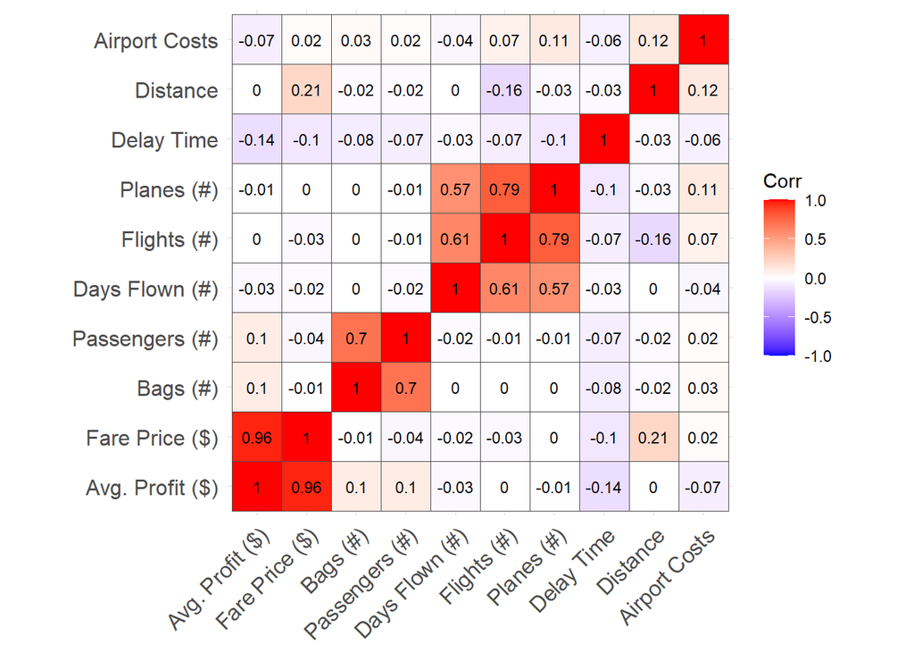

Figure 14: Correlation heatmap displaying key profitability components

```r
# Summary Stats for key profit components by route/carrier w 10+ flights
flights_medlarge_roundtrip |>
  flightdicer(grp1 = route_iata,
              grp2 = op_carrier,
              min_flights = 10) |>
  arrange(desc(avg_profit)) |>
  select(`Flights (#)` = n_flights,
         `Planes (#)` = n_planes,
         `Days Flown (#)` = n_flightdays,
         `Avg. Profit ($)` = avg_profit,
         `Fare Price ($)` = avg_median_fare,
         `Bags (#)` = avg_n_bags,
         `Passengers (#)` = avg_n_passengers,
         `Distance` = avg_distance,
         `Airport Costs` = avg_airport_costs,
         `Delay Time` = avg_delay_time) -> key_driver_summary

# Correlation Matrix
cor(key_driver_summary) -> profit_cormat_routes_carriers
# P-values for test of signifance re: correlations
cor_pmat(key_driver_summary) -> profit_cormat_routes_carriers_pvals

# Prettier with LABELS
ggcorrplot(profit_cormat_routes_carriers, method = "square",
           hc.order = T, outline.color = "grey30",lab_size = 3,
           lab = T)
```

### 4.3.2 Driver Takeaways

# 5 Final Recommendation

Based on the findings detailed above, the limitations imposed by only having 5 planes, and the brand commitment to punctuality, the following approach is suggested:

1. Identify the top 25 most-profitable specific `route/carrier` combinations
2. Use quantile ranks to filter these 25 flights for those with higher `ticket_fares`, shorter `distances`, lower `delay_times`, and greater `occupancy_rates`
   1. Focusing on reduced delay_times and distance also supports the key brand component of punctuality
3. Emulate the approach of highly-profitable low-volume regional airlines

## 5.1 Top 5 Recommended Routes

In following this approach, we land upon the final 5 routes:

```r
# Summary Stats for flights ordered by average profit
flights_medlarge_roundtrip |>
  flightdicer(grp1 = route_iata,
              grp2 = op_carrier,
              min_flights = 10) |>
  arrange(desc(avg_profit)) |>
  # Filter for top 25 profit levels
  slice_max(avg_profit, n = 25) |>
  # Filter for top quantile fare and occupancy rate, low tile distance and delay
  filter(avg_median_fare_decile == 20,
         avg_occupancy_rate_decile >= 15,
         avg_distance_decile <= 5,
         avg_delay_time_decile <= 5) |>
  select(route_iata, op_carrier, avg_profit) -> finaltop5

# Pull in full route name for clarity
finaltop5 |>
  left_join(flights_medlarge_roundtrip |>
              distinct(route_iata, route_city_name),
            by = c("route_iata")) |>
  gt() |>
  tab_header(title = md("**Final Top 5 Routes**"))
```

Table 4: Final top 5 routes based on profit, delay, distance, occupancy, and fares

**Final Top 5 Routes**

| route_iata | op_carrier | avg_profit | route_city_name |
| --- | --- | --- | --- |
| CLT-RDU | OH | 308462.6 | Charlotte, NC-Raleigh/Durham, NC |
| CLT-ILM | AA | 227219.8 | Charlotte, NC-Wilmington, NC |
| DTW-IND | OO | 190335.6 | Detroit, MI-Indianapolis, IN |
| CLE-DTW | 9E | 180941.8 | Cleveland, OH-Detroit, MI |
| ATL-LEX | DL | 170716.1 | Atlanta, GA-Lexington, KY |

**Quantiles used for selecting routes range from 1 to 20 on each metric, where the 20th quantile corresponds to the top 5% raw values of each metric, and the 1st quintile equates to the bottom 5% raw values**

## 5.2 ROI to Break Even

```r
finaltop5 |>
  mutate(n_flights_breakeven = round(90000000/avg_profit)) |>
  gt() |>
  tab_header(title = md("**Number of Flights Required to Recoup Plane Investment**"))
```

**Number of Flights Required to Recoup Plane Investment**

| route_iata | op_carrier | avg_profit | n_flights_breakeven |
| --- | --- | --- | --- |
| CLT-RDU | OH | 308462.6 | 292 |
| CLT-ILM | AA | 227219.8 | 396 |
| DTW-IND | OO | 190335.6 | 473 |
| CLE-DTW | 9E | 180941.8 | 497 |
| ATL-LEX | DL | 170716.1 | 527 |

## 5.3 KPI Monitoring

The following KPIs should be monitored to track progress going forward:

1. All metrics involved in profitability calculations
   1. `distance`, `number_flights`, `occupancy_rate`, `ticket_fares`, `operational_costs`, `baggage_fees`, `delay_time`
2. Proportion of on-time flights and resulting customer satisfaction (via survey data)
3. Number of round-trip flights that a single plane can take in a single flight day
   1. Monitor demand and `occupancy_rate` to gauge if customer appetite is there for 2+ flights a day on the shorter-distance routes

### 5.3.1 Additional Considerations & Limitations

The following considerations should also be taken into account:

1. All analyses are based only on 1Q2019 data, and the world has certainly changed since then
2. Seasonality is not taken into account, and that is arguably one of the biggest factors in airline profit
   1. Especially critical given `ticket_fares` are the biggest lever in profitability
3. Profitability estimates don’t take into account the infrastructure and efficiency advantage that some of the major carriers have, particularly at their hubs (e.g. Delta’s `ATL` hub)
   1. Unrealistic to truly assume static universal operational costs
   2. Hub-based model is critical to modern airline efficiency

# 6 Appendix

## 6.1 Cost & Revenue Assumptions

Calculations included the following assumptions:

### 6.1.1 Costs

- Mileage-variable costs totaling $9.18/mile
  - $8.00 for fuel, oil, maintenance, crew
  - $1.18 for depreciation, insurance, other
  - Plane make/model variations not considered
- Airport operational costs based on landing airport size assessed once per flight leg
  - $5000 for medium-size
  - $10000 for large-size
- Delay costs can be assessed a total of 4 times as there are 2 flight legs that each have a departure and an arrival
  - Each departure and arrival given initial 15 minute grace period
  - $75 charged for every minute of delays past the grace period
  - Delays calculated separately for each departure and arrival, such that early arrivals or departures do not detract from earlier delay costs
- Plane cost fixed at $90 million per plane
  - Plane cost was *not* considered in profitability, but *was* considered when calculating expected break-even points